# Practical Machine Learning: Course Project

Weight Lifting Exercise Dataset

Rob Willhoft

12/07/2019

# Background

Using devices such as Jawbone Up, Nike FuelBand, and Fitbit it is now possible to collect a large amount of data about personal activity relatively inexpensively. These type of devices are part of the quantified self movement – a group of enthusiasts who take measurements about themselves regularly to improve their health, to find patterns in their behavior, or because they are tech geeks. One thing that people regularly do is quantify how much of a particular activity they do, but they rarely quantify how well they do it. In this project, your goal will be to use data from accelerators on the belt, forearm, arm, and dumbbell of 6 participants. They were asked to perform barbell lifts correctly and incorrectly in 5 different ways. More information is available from the website here: http://groupware.les.inf.puc-rio.br/har (see the section on the Weight Lifting Exercise Dataset).

## Data

The training data was loaded from this link:

https://d396qusza40orc.cloudfront.net/predmachlearn/pml-training.csv

And the test data was loaded with this link:

https://d396qusza40orc.cloudfront.net/predmachlearn/pml-testing.csv

## Acknowledgement

Data is from: Velloso, E.; Bulling, A.; Gellersen, H.; Ugulino, W.; Fuks, H. Qualitative Activity Recognition of Weight Lifting Exercises. Proceedings of 4th International Conference in Cooperation with SIGCHI (Augmented Human ’13) . Stuttgart, Germany: ACM SIGCHI, 2013.

**Source**: http://groupware.les.inf.puc-rio.br/har#ixzz67OYDp5fD

I want to acknowledge them as being very generous in allowing their data to be used for this kind of assignment.

# Summary

The goal of your project is to predict the manner in which the participants did the exercise. This is the “classe” variable in the training set. This report will talk about:

1. The variables used to predict, including data cleaning.
2. The method used to build the model.
3. The use of cross validation to evaluate the model
4. Estimates of the sample error.

Each step will describe the choices made that led to the final prediction model.

Finally, the prediction model to predict 20 different test cases. Note, as good practice requires these are not used in any of the steps outlined.

## Loading Data

The files downloaded from the above links were CSV files and so the following code is used to load the taring data into R.

```r
training = read.csv("data/pml-training.csv")
dim(training)
```

```
## [1] 19622   160
```

```r
testing = read.csv("data/pml-testing.csv")
dim(testing)
```

```
## [1]  20 160
```

# Cleaning the Data

## Removing Non-Measurement Data

The first five variables in the data set are an index number, participant ID, and time stamp information. These are removed.

```r
training <- training[, -c(1,2,3,4,5)]
testing <- testing[, -c(1,2,3,4,5)]
```

## Remove NAs

There are 67 variables where the bulk of the data is NA, 19216 of the 19622 data samples. This seems excessive for any form of interpolation, so these variables are just removed from the training and testing data sets.

```r
isNA <- is.na(training)
table(apply(isNA, 2, sum))
```

```
##
##     0 19216
##    88    67
```

```r
training <- training[,!apply(isNA, 2, any)]
testing <- testing[,!apply(isNA, 2, any)]
```

## Remove Blank Data

There are also variables in the data set that have a large number of blanks. The following code uses a threshold of 19000 samples (over 96%) of the data being blank to decide what variables to remove.

```r
isBlank <- apply(training == "",2,sum) > 19000
training <- training[, !isBlank]
testing <- testing[, !isBlank]
```

## Final Data Set

The final data set has 55 variables. All are numeric except the first (`new window`) and the `classe` (last variable). The following variables are included in the data:

```r
names(training)
```

```
##  [1] "new_window"           "num_window"           "roll_belt"
##  [4] "pitch_belt"           "yaw_belt"             "total_accel_belt"
##  [7] "gyros_belt_x"         "gyros_belt_y"         "gyros_belt_z"
## [10] "accel_belt_x"         "accel_belt_y"         "accel_belt_z"
## [13] "magnet_belt_x"        "magnet_belt_y"        "magnet_belt_z"
## [16] "roll_arm"             "pitch_arm"            "yaw_arm"
## [19] "total_accel_arm"      "gyros_arm_x"          "gyros_arm_y"
## [22] "gyros_arm_z"          "accel_arm_x"          "accel_arm_y"
## [25] "accel_arm_z"          "magnet_arm_x"         "magnet_arm_y"
## [28] "magnet_arm_z"         "roll_dumbbell"        "pitch_dumbbell"
## [31] "yaw_dumbbell"         "total_accel_dumbbell" "gyros_dumbbell_x"
## [34] "gyros_dumbbell_y"     "gyros_dumbbell_z"     "accel_dumbbell_x"
## [37] "accel_dumbbell_y"     "accel_dumbbell_z"     "magnet_dumbbell_x"
## [40] "magnet_dumbbell_y"    "magnet_dumbbell_z"    "roll_forearm"
## [43] "pitch_forearm"        "yaw_forearm"          "total_accel_forearm"
## [46] "gyros_forearm_x"      "gyros_forearm_y"      "gyros_forearm_z"
## [49] "accel_forearm_x"      "accel_forearm_y"      "accel_forearm_z"
## [52] "magnet_forearm_x"     "magnet_forearm_y"     "magnet_forearm_z"
## [55] "classe"
```

# Decision Tree

The first model that was explored was based on decision trees. It processed quickly, but had fairly poor prediction success on the taring data, less than 50%.

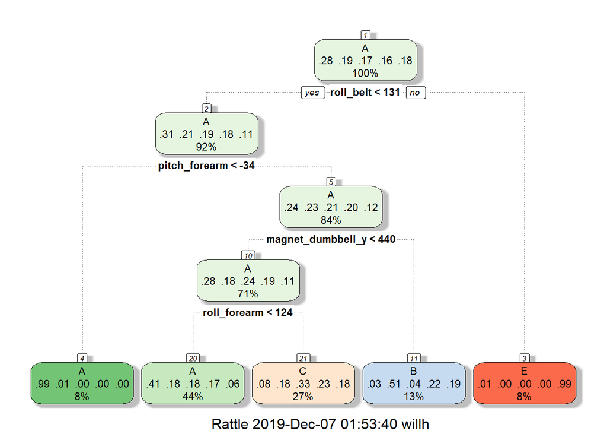

```r
library(caret)
treeFit <- train(classe ~ .,
                 method="rpart",
                 data=training)
library(rattle)
fancyRpartPlot(treeFit$finalModel)
```

```r
treePred = predict(treeFit, training)
predTable <- table(treePred, training$classe)
predTable
```

```
##
## treePred    A    B    C    D    E
##        A 5080 1581 1587 1449  524
##        B   81 1286  108  568  486
##        C  405  930 1727 1199  966
##        D    0    0    0    0    0
##        E   14    0    0    0 1631
```

```r
sum(diag(predTable)) / nrow(training)
```

```
## [1] 0.4955662
```

The first attempt to improve this involved reprocessing the data by adding `preProcess = c("center", "scale")` to the `train` function call. This made little difference.

## Correlated Predictors

The correlations were calculated using the `cor` function. Eight groups were found with 2 to 5 variables in the group. These groups were combined with the average of the values. This reduced the number of variables to 41 (i.e. 22 variables were combined into 8 new variables.) Although the decision tree was different, there was very little difference in the prediction success.

# Parallel Processing

The following model fits were very slow in executing, to help with this, parallel processing was enabled.

## Setup Parallel Processing

```r
library(parallel)
library(doParallel)
cluster <- makeCluster(detectCores() - 1) # leave one for for OS
registerDoParallel(cluster)
parallelControl <- trainControl(method = "cv",
                           number = 5,
                           allowParallel = TRUE)
```

Reference: https://github.com/lgreski/datasciencectacontent/blob/master/markdown/pml-randomForestPerformance.md

## Failed Methods due to Processing Complexity

Ultimately, both Random Forest and Naive Bayes failed to produce a result in a reasonable time, i.e. less than 1/2 hour, even with parallel processing on an Intel i5. The the is included here, but was ultimately abandoned.

### Random Forest

```
rfFit <- train(classe ~ .,
               data=training,
               method="rf",
               prox=TRUE,
               trControl = fitControl)
randomForest::getTree(rfFit$finalModel, k=2)
```

### Naive Bayes

```
library(lda)
library(klaR)
library(e1071)
nbFit = train(classe ~ ., data=training, method="nb")
```

# Boosting

The next model explored was Boosting. This produces a greater than 90% prediction success.

```r
boostFit <- train(classe ~ ., method = "gbm", data = training,
                  verbose = FALSE, trControl = parallelControl)
```

## Cross-Validation

5-fold resampling was done for cross-validation and the results are given as part of the model fit below. The accuracy is fairly good from 0.76 to 0.98.

```r
boostFit
```

```
## Stochastic Gradient Boosting
##
## 19622 samples
##    54 predictor
##     5 classes: 'A', 'B', 'C', 'D', 'E'
##
## No pre-processing
## Resampling: Cross-Validated (5 fold)
## Summary of sample sizes: 15699, 15698, 15697, 15697, 15697
## Resampling results across tuning parameters:
##
##   interaction.depth  n.trees  Accuracy   Kappa
##   1                   50      0.7598112  0.6952691
##   1                  100      0.8318735  0.7871473
##   1                  150      0.8705544  0.8361629
##   2                   50      0.8836007  0.8526175
##   2                  100      0.9416985  0.9262367
##   2                  150      0.9650904  0.9558365
##   3                   50      0.9343599  0.9169108
##   3                  100      0.9727858  0.9655700
##   3                  150      0.9871064  0.9836891
##
## Tuning parameter 'shrinkage' was held constant at a value of 0.1
##
## Tuning parameter 'n.minobsinnode' was held constant at a value of 10
## Accuracy was used to select the optimal model using the largest value.
## The final values used for the model were n.trees = 150,
##  interaction.depth = 3, shrinkage = 0.1 and n.minobsinnode = 10.
```

```r
boostPred = predict(boostFit, training)
predTable <- table(boostPred, training$classe)
predTable
```

```
##
## boostPred    A    B    C    D    E
##         A 5574   33    0    4    0
##         B    6 3742   18   12    5
##         C    0   21 3400   28    6
##         D    0    1    3 3172   20
##         E    0    0    1    0 3576
```

```r
sum(diag(predTable)) / nrow(training)
```

```
## [1] 0.9919478
```

# Final Prediction of Test values

Finally, the `boostFit` model is used to predict that values of the testing data set.

```r
boostTest = predict(boostFit, testing)
boostTest
```

```
##  [1] B A B A A E D B A A B C B A E E A B B B
## Levels: A B C D E
```